## Setup

### Load packages

```r
library(ggplot2)
library(dplyr)
library(statsr)
library(BAS)
library(broom)
```

### Load data

Make sure your data and R Markdown files are in the same directory. When loaded your data file will be called `movies`. Delete this note when before you submit your work.

```r
load("/Users/JJHunt/Desktop/movies.RData")
```

## Part 1: Data

The data set claims to be a random sample of movies made before 2016, so conclusions should be generalizable to all movies before 2016. However, very old mvies from the 20’s do not appear in the dataset, so there must be some start date to their sample. Additionally, very unpopular movies might be so unknown that it was diffcult to include them in the sample. Therefore, our generalizability to all movies before 2016 is dubios.

The data is observational. No random assignment was used, so causation cannot be established.

## Part 2: Data manipulation

I use the if-else function to mark whether movies are feature films.

```r
movies <- movies %>% mutate(feature_film = ifelse(title_type == "Feature Film", "Yes", "No"))
```

I use the if-else function to mark whether movies are dramas.

```r
movies <- movies %>% mutate(drama = ifelse(genre == "Drama", "Yes", "No"))
```

I use the if-else function to mark whether movies are rated R.

```r
movies <- movies %>% mutate(mpaa_rating_R = ifelse(mpaa_rating == "R", "Yes", "No"))
```

I use the if-else function to mark whether movies were released in Oscar season.

```r
movies <- movies %>% mutate(oscar_season = ifelse(thtr_rel_month == "10"|thtr_rel_month == "11"|thtr_rel_month == "12", "Yes", "No"))
```

I use the if-else function to mark whether movies were released in the summer.

```r
movies <- movies %>% mutate(summer_season = ifelse(thtr_rel_month == "5"|thtr_rel_month == "6"|thtr_rel_month == "7" | thtr_rel_month == "8", "Yes", "No"))
```

## Part 3: Exploratory data analysis

Surprisingly, feature films have a substantially lower mean and median audience score. There are many fewer non-feature films in the sample. Parhaps the non-features films selected for the sample happen to be well known and particularly good.

```r
movies %>% group_by(feature_film) %>% summarise(n=n(), mean_score=mean(audience_score), median_score=median(audience_score))
```

```
## # A tibble: 2 x 4
##   feature_film     n mean_score median_score
##   <chr>        <int>      <dbl>        <dbl>
## 1 No              60       81.0         85.5
## 2 Yes            591       60.5         62
```

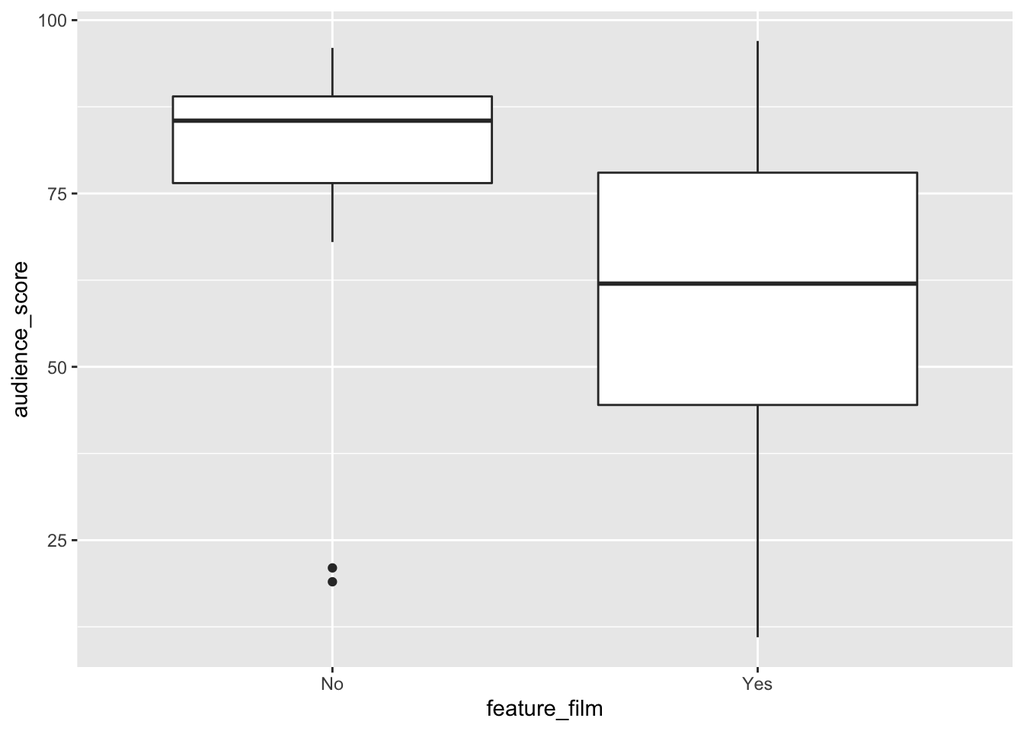

```r
ggplot(movies, aes(x=feature_film, y=audience_score)) + geom_boxplot()
```

```r
movies %>% group_by(drama) %>% summarise(n=n(), mean_score=mean(audience_score), median_score=median(audience_score))
```

```
## # A tibble: 2 x 4
##   drama     n mean_score median_score
##   <chr> <int>      <dbl>        <dbl>
## 1 No      346       59.7           61
## 2 Yes     305       65.3           70
```

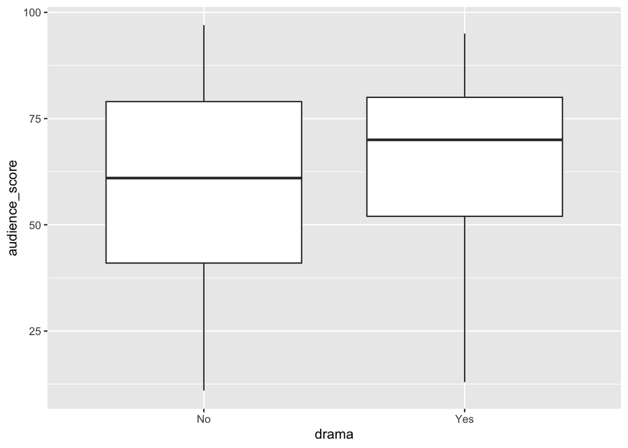

```r
ggplot(movies, aes(x=drama, y=audience_score)) + geom_boxplot()
```

```r
movies %>% group_by(mpaa_rating_R) %>% summarise(n=n(), mean_score=mean(audience_score), median_score=median(audience_score))
```

```
## # A tibble: 2 x 4
##   mpaa_rating_R     n mean_score median_score
##   <chr>         <int>      <dbl>        <dbl>
## 1 No              322       62.7         65.5
## 2 Yes             329       62.0         64
```

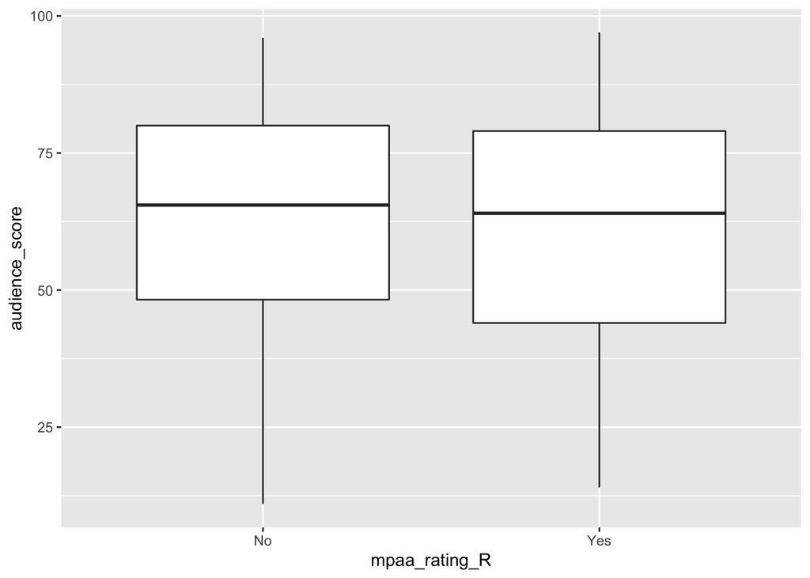

```r
ggplot(movies, aes(x=mpaa_rating_R, y=audience_score)) + geom_boxplot()
```

The movies released in Oscar season have a higher median score and a somewhat higher mean score.

```r
movies %>% group_by(oscar_season) %>% summarise(n=n(), mean_score=mean(audience_score), median_score=median(audience_score))
```

```
## # A tibble: 2 x 4
##   oscar_season     n mean_score median_score
##   <chr>        <int>      <dbl>        <dbl>
## 1 No             460       61.8           64
## 2 Yes            191       63.7           69
```

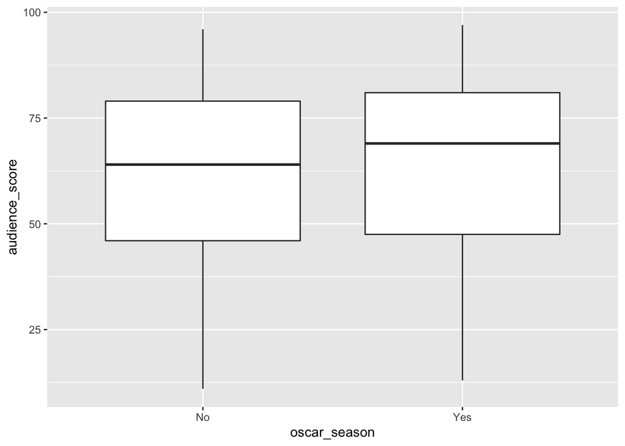

```r
ggplot(movies, aes(x=oscar_season, y=audience_score)) + geom_boxplot()
```

Movies released in the summer have virtually identical audience scores, being very slightly lower in their median and mean.

```r
movies %>% group_by(summer_season) %>% summarise(n=n(), mean_score=mean(audience_score), median_score=median(audience_score))
```

```
## # A tibble: 2 x 4
##   summer_season     n mean_score median_score
##   <chr>         <int>      <dbl>        <dbl>
## 1 No              443       62.6           66
## 2 Yes             208       61.8           65
```

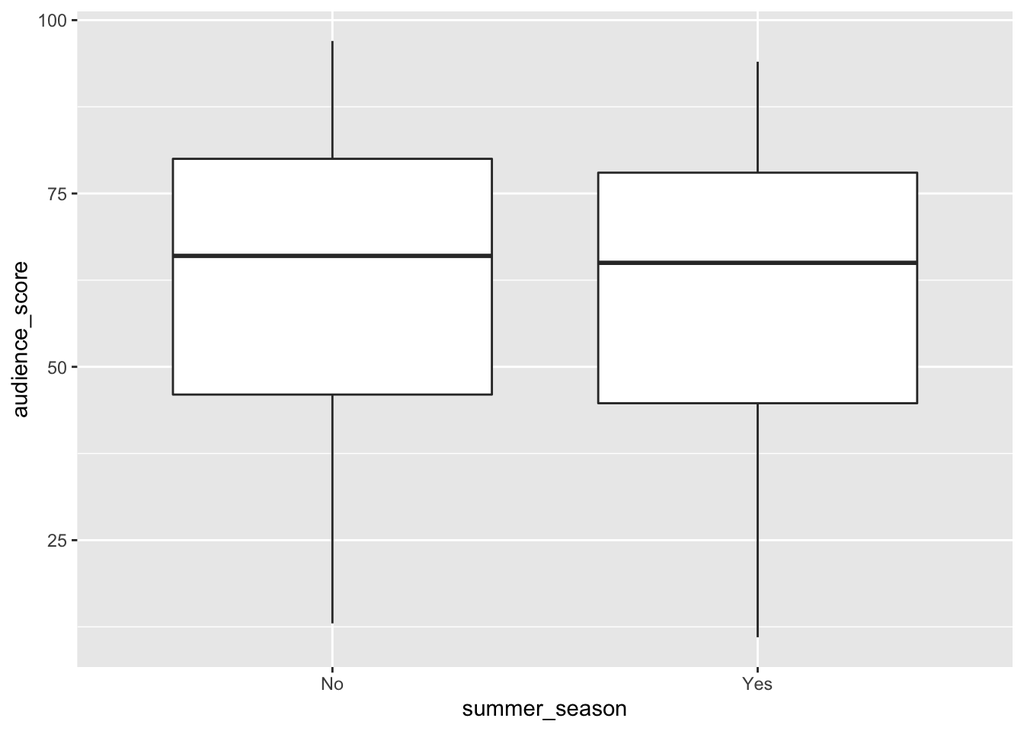

```r
ggplot(movies, aes(x=summer_season, y=audience_score)) + geom_boxplot()
```

## Part 4: Modeling

Here, I generate a series of models that are permutations of all the listed variables. I start with a line of code (na.omit) that will exclude any movies with missing observations. The computer generates many models, and the models are then ranked according to their BIC. Only the best five models are shown.

```r
movies_no_na <- na.omit(movies)
bma_audience_score <- bas.lm(audience_score ~ feature_film+drama+runtime+mpaa_rating_R+thtr_rel_year+oscar_season+summer_season+imdb_rating+imdb_num_votes+critics_score+best_pic_nom+best_pic_win+best_actor_win+best_actress_win+best_dir_win+top200_box, movies_no_na, prior = "BIC", modelprior = uniform())


round(summary(bma_audience_score), 3)
```

```
##                     P(B != 0 | Y)   model 1   model 2   model 3   model 4
## Intercept                   1.000     1.000     1.000     1.000     1.000
## feature_filmYes             0.059     0.000     0.000     0.000     0.000
## dramaYes                    0.045     0.000     0.000     0.000     0.000
## runtime                     0.514     1.000     0.000     0.000     1.000
## mpaa_rating_RYes            0.165     0.000     0.000     0.000     1.000
## thtr_rel_year               0.081     0.000     0.000     0.000     0.000
## oscar_seasonYes             0.065     0.000     0.000     0.000     0.000
## summer_seasonYes            0.079     0.000     0.000     0.000     0.000
## imdb_rating                 1.000     1.000     1.000     1.000     1.000
## imdb_num_votes              0.062     0.000     0.000     0.000     0.000
## critics_score               0.920     1.000     1.000     1.000     1.000
## best_pic_nomyes             0.132     0.000     0.000     0.000     0.000
## best_pic_winyes             0.041     0.000     0.000     0.000     0.000
## best_actor_winyes           0.116     0.000     0.000     0.000     0.000
## best_actress_winyes         0.148     0.000     0.000     1.000     0.000
## best_dir_winyes             0.067     0.000     0.000     0.000     0.000
## top200_boxyes               0.049     0.000     0.000     0.000     0.000
## BF                             NA     1.000     0.872     0.205     0.204
## PostProbs                      NA     0.156     0.136     0.032     0.032
## R2                             NA     0.748     0.746     0.747     0.750
## dim                            NA     4.000     3.000     4.000     5.000
## logmarg                        NA -3434.752 -3434.889 -3436.338 -3436.342
##                       model 5
## Intercept               1.000
## feature_filmYes         0.000
## dramaYes                0.000
## runtime                 1.000
## mpaa_rating_RYes        0.000
## thtr_rel_year           0.000
## oscar_seasonYes         0.000
## summer_seasonYes        0.000
## imdb_rating             1.000
## imdb_num_votes          0.000
## critics_score           1.000
## best_pic_nomyes         1.000
## best_pic_winyes         0.000
## best_actor_winyes       0.000
## best_actress_winyes     0.000
## best_dir_winyes         0.000
## top200_boxyes           0.000
## BF                      0.185
## PostProbs               0.029
## R2                      0.750
## dim                     5.000
## logmarg             -3436.438
```

The best model includes runtime, imbd rating, and critics score. The second best model, which is not very far behind, just uses imbd rating and critics score, so those explanatory variables are most important.

Now, I rename the best model (the model including runtime, imbd rating, and critics score) as “m_audience_score_red” or “bma_audience_score_red”. “red” stands for reduced, because this stripped down model has filtered out the unnecessary explanatory variables. The bayesian model has a bma tag, and the regular model has an m tag. The Bayesian model will be used to calculate credible intervals for the coefficients. The regular model will be used later in my prediction.

```r
m_audience_score_red <- lm(audience_score ~ runtime+imdb_rating+critics_score, movies)

bma_audience_score_red <- bas.lm(data=movies_no_na, audience_score ~ runtime+imdb_rating+critics_score,prior= 'BIC', modelprior = uniform())
```

Now, I will calculate the coefficients of the variables and their 95% credible intervals.

```r
coef_bma_audience_score_red = coefficients(bma_audience_score_red)

confint(coef_bma_audience_score_red)
```

```
##                      2.5%      97.5%        beta
## Intercept     61.43267770 63.0339281 62.21001616
## runtime       -0.08889169  0.0000000 -0.03138428
## imdb_rating   13.47639676 16.4299404 14.89079350
## critics_score  0.00000000  0.1122528  0.07128748
## attr(,"Probability")
## [1] 0.95
## attr(,"class")
## [1] "confint.bas"
```

We find that Imdb score has a large positive effect on audience score. Critic score has a very small positive effect. Runtime has an effect that is similar in its small size but negative.

Now, I will run the model diagnostics. The augment function calculates residual values and the standardized residuals. I will do this three seperate times to ensure that our three seperate explanatory variables have a roughly linear relationship with audience score.

In each of these cases, I will generate a single variable model. Then, I will use the augment function to calculate the residuals and standardized residuals for each the model. Then, I will graph the residuals versus the fitted values (to check for constant variance), graph a histogram of residual values (to check for normal disctribution of residuals), and graph the theoretical quantiles versus the standardized residuals.

First, run time versus audience score.

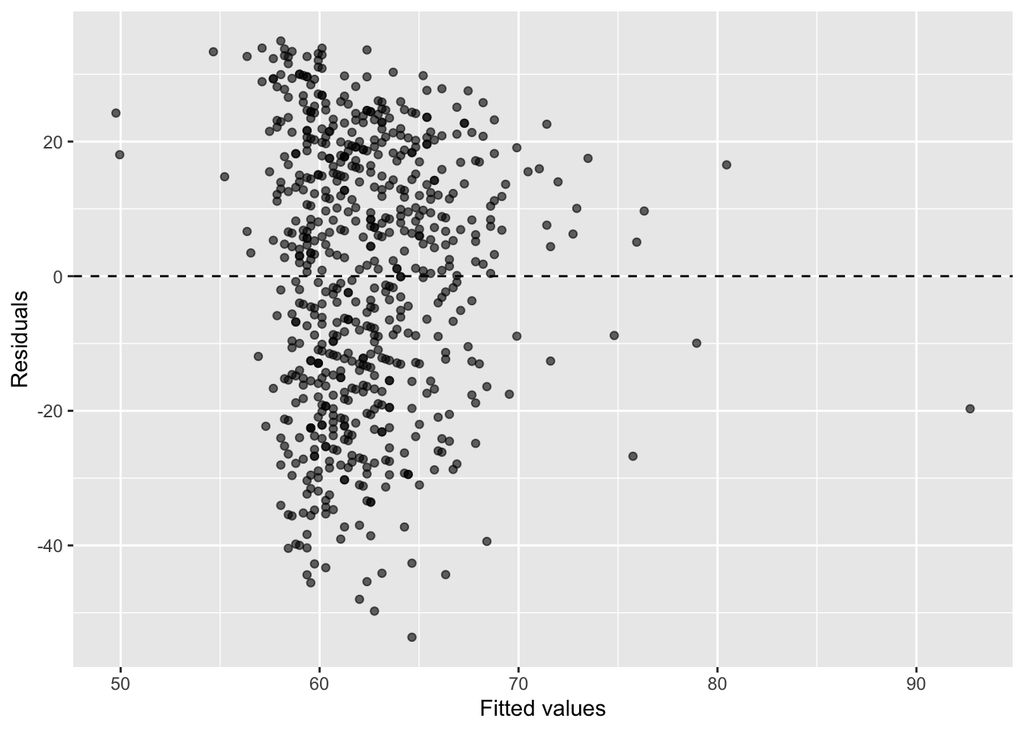

```r
m_runtime <- lm(audience_score ~ runtime, movies)
m_runtime_aug <- augment(m_runtime)

ggplot(data = m_runtime_aug, aes(x = .fitted, y = .resid)) +
  geom_point(alpha = 0.6) +
  geom_hline(yintercept = 0, linetype = "dashed") +
  labs(x = "Fitted values", y = "Residuals")
```

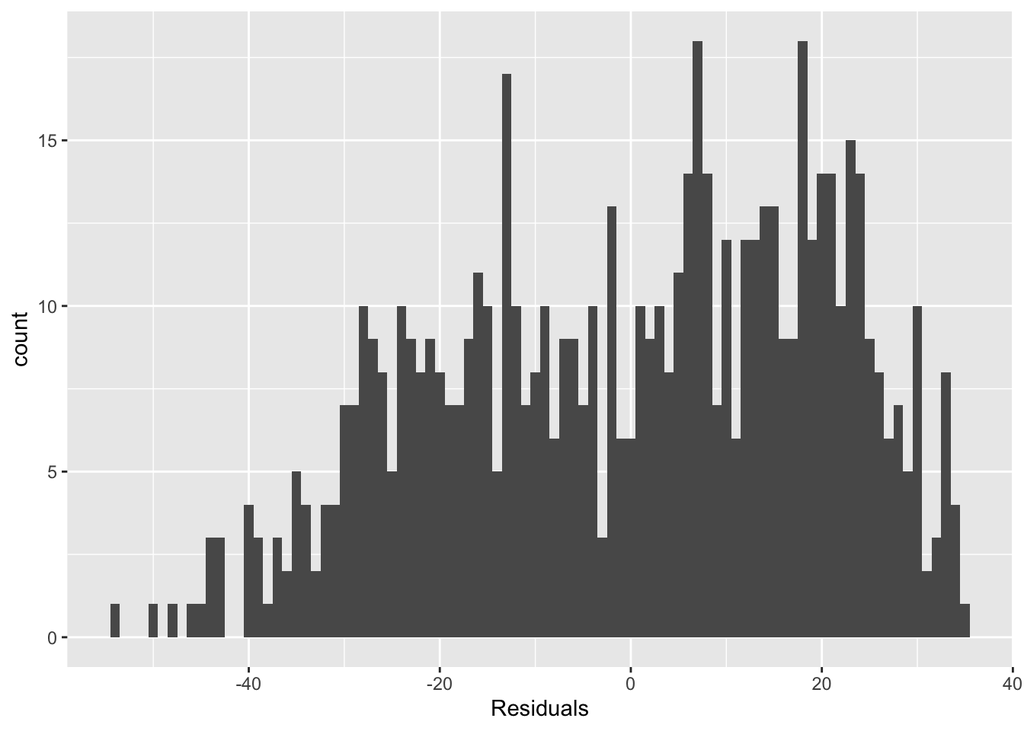

```r
ggplot(data = m_runtime_aug, aes(x = .resid)) +
  geom_histogram(binwidth = 1) +
  xlab("Residuals")
```

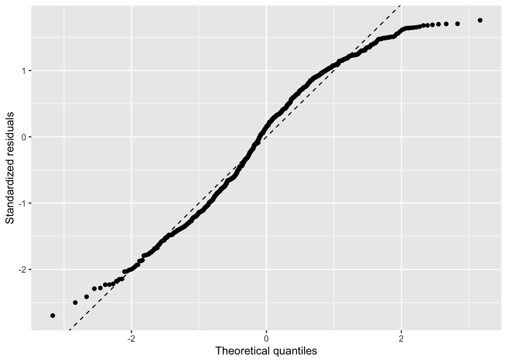

```r
ggplot(m_runtime_aug) +
  geom_qq(aes(sample = .std.resid)) +
  geom_abline(slope = 1, intercept = 0, linetype = "dashed") +
  labs(x = "Theoretical quantiles", y = "Standardized residuals")
```

Second, imdb rating versus audience score.

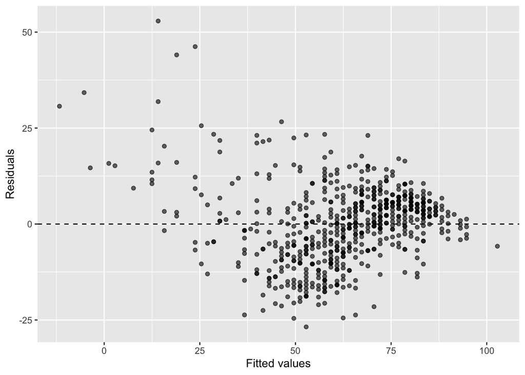

```r
m_imdb_rating <- lm(audience_score ~ imdb_rating, movies)
m_imdb_rating_aug <- augment(m_imdb_rating)

ggplot(data = m_imdb_rating_aug, aes(x = .fitted, y = .resid)) +
  geom_point(alpha = 0.6) +
  geom_hline(yintercept = 0, linetype = "dashed") +
  labs(x = "Fitted values", y = "Residuals")
```

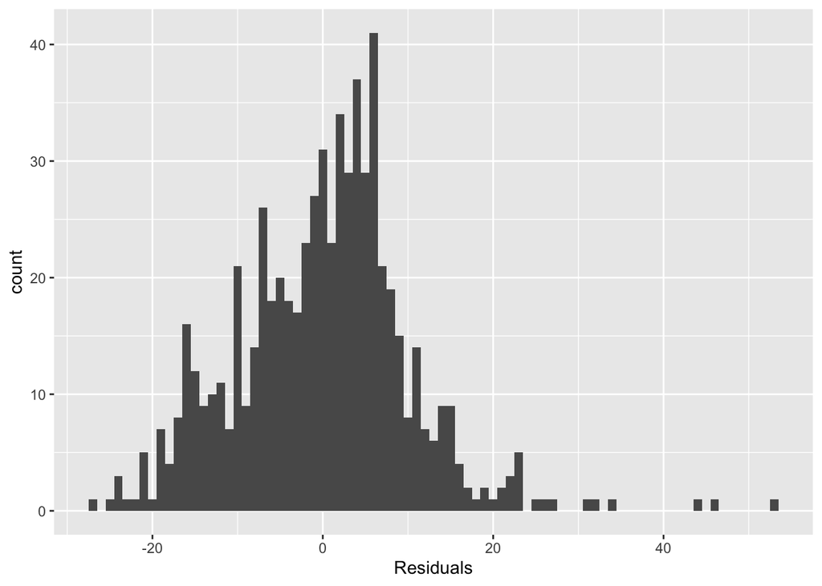

```r
ggplot(data = m_imdb_rating_aug, aes(x = .resid)) +
  geom_histogram(binwidth = 1) +
  xlab("Residuals")
```

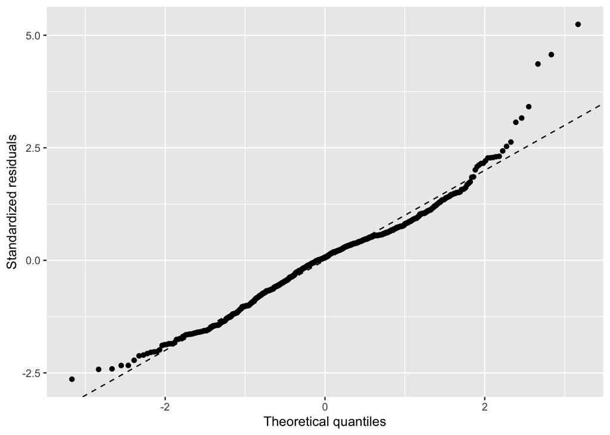

```r
ggplot(m_imdb_rating_aug) +
  geom_qq(aes(sample = .std.resid)) +
  geom_abline(slope = 1, intercept = 0, linetype = "dashed") +
  labs(x = "Theoretical quantiles", y = "Standardized residuals")
```

The residuals do not have constant variance. However, the main problem seems to be outliers on the low end of the fitted value spectrum. Then, the residuals seem to be close to normally distributed with some outlying residuals way above the line of best fit.

Third, critics score versus audience score.

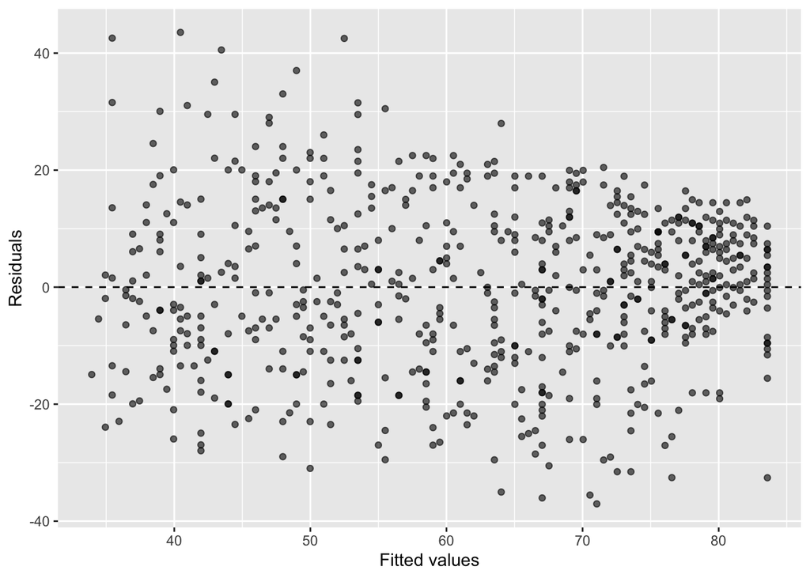

```r
m_critics_score <- lm(audience_score ~ critics_score, movies)
m_critics_score_aug <- augment(m_critics_score)

ggplot(data = m_critics_score_aug, aes(x = .fitted, y = .resid)) +
  geom_point(alpha = 0.6) +
  geom_hline(yintercept = 0, linetype = "dashed") +
  labs(x = "Fitted values", y = "Residuals")
```

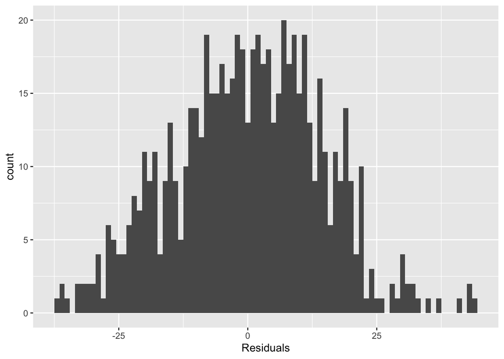

```r
ggplot(data = m_critics_score_aug, aes(x = .resid)) +
  geom_histogram(binwidth = 1) +
  xlab("Residuals")
```

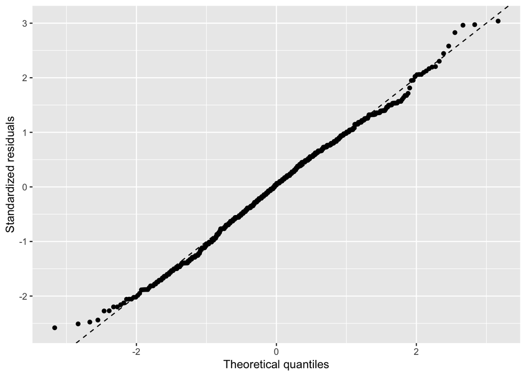

```r
ggplot(m_critics_score_aug) +
  geom_qq(aes(sample = .std.resid)) +
  geom_abline(slope = 1, intercept = 0, linetype = "dashed") +
  labs(x = "Theoretical quantiles", y = "Standardized residuals")
```

Here, the variance seems very close to normal, and the residuals are very close to normally distributed. This close relatioship might be, beacuse the rotten tomatoes audience score and rotten tomatoes critics score might have a tigher relationship compared to imdb.

## Part 5: Prediction

Here I make a prediction. The first line of code takes in the old baysian model using all the potential and spits out the best out the most predictive model. The secod line of code then spits out the variables in the model.

```r
BPM_pred_aud_score <- predict(bma_audience_score, estimator = "BPM", se.fit = TRUE)
variable.names(BPM_pred_aud_score)
```

```
## [1] "Intercept"     "runtime"       "imdb_rating"   "critics_score"
```

These three variables are the same three that the BIC method found to be the best. This confirms that we should use this three variable model. Remember, I named this model “m_audience_score_red” up above.

I picked the 2016 movie Passengers, a scifi movie starring Jennifer Lawrence and Chris Pratt. Here is where I found the imdb score (7.0) and the runtime (116). https://www.imdb.com/title/tt1355644/ Here is the rotten tomatoes critics score (31) and audience score (63): https://www.rottentomatoes.com/m/passengers_2016

The first line creates the passengers data frame with the relevent information. The second line makes a prediction using our three variable model and shows the 95% credible interval on that prediction.

```r
passengers <- data.frame(runtime = 116, imdb_rating = 7.0, critics_score = 31)
predict(m_audience_score_red, passengers, interval = "prediction", level = 0.95)
```

```
##        fit      lwr      upr
## 1 67.54384 47.74636 87.34132
```

The predicted value 67.5 is pretty close to the actual value of 63. We can see from the wide 95% credibility interval that our model cannot make very precise predictions.

## Part 6: Conclusion

We discovered that run time, Imdb rating, and critics score were the best predictors of a movie’s audience rating. The movie we used to test predictive power had an audience score very close to the one we predicted. We could see from run time’s non-normal distribution of residuals that this explanatory variable has the weakest connection. Based on the model diagnostics, run time has the least linear relationship with audience score, I suspect becuase the relatioship is not direct but mediated by studio confidence. It is obvious why Imdb rating and critics score would be correlated with audience score; they are all trying to approximate quality.

The study has two potential shortcomings. First, the data set may not be generalizable. The high quality of non-feature films suggested that worse known movies had trouble being included. Therefore, we can not generalize to all movies before 2016. Second, the relationship of imdb rating or run time was not fully linear with audience score, so there may be misleading elements in the model. However, the BIC test indicated that these two variables were still useful.